# Experimental treatment with edaravone in a mouse model of spinocerebellar ataxia 1

Calbindin immunofluorescence intensity

Author

Martina Sucha, Simona Benediktova, Filip Tichanek, Jan Jedlicka, Stepan Kapl, Dana Jelinkova, Zdenka Purkartova, Jan Tuma, Jitka Kuncova, Jan Cendelin

This page shows R code for the study [Sucha et al.](https://www.mdpi.com/1422-0067/24/13/10689) (2023, *International Journal of Molecular Science*).

**Citation**:

> Sucha M, Benediktova S, Tichanek F, Jedlicka J, Kapl S, Jelinkova D, Purkartova Z, Tuma J, Kuncova J, Cendelin J. Experimental Treatment with Edaravone in a Mouse Model of Spinocerebellar Ataxia 1. International Journal of Molecular Sciences. 2023; 24(13):10689. https://doi.org/10.3390/ijms241310689

[GitHub page](https://github.com/filip-tichanek/edaravonSCA1): https://github.com/filip-tichanek/edaravonSCA1

# 1 Upload of packages

```r
rm(list = ls())

suppressWarnings(suppressMessages( {
library(brms)
library(beeswarm)
library(vioplot)
library(glmmTMB)
library(car)
library(cowplot)
library(ggplot2)
library(tidyverse)
library(bayesplot)
library(gtsummary)
library(vegan)
library(knitr)
library(ggplot2)
  } ) )
```

# 2 Data upload and wrangling

```r
## Data upload
load("source_data/myEnvironment.RData")

## Defining new variables
calb <- calb %>% rename(reg = CbRegion.vermis_hemispheres.)
calb$group_region <- interaction(calb$reg, calb$group)
levels(calb$group_region)
```

```
[1] "hemispheres.ctrl.wt"  "vermis.ctrl.wt"       "hemispheres.ctrl.sca"
[4] "vermis.ctrl.sca"      "hemispheres.eda.sca"  "vermis.eda.sca"
```

```r
#calb$reg <- ifelse(calb$reg == 'hemispheres', 0.5, -0.5)
calb$mean_gran <- scale(calb$mean_gran)
calb$group_region <- interaction(calb$group, calb$reg)

## re-ordering factor levels
calb$group<-relevel(calb$group,ref='ctrl.sca')

## data summary
summary(calb)
```

```
       id      treatment  genotype  sex         slice        order
 15     : 80   ctrl:596   sca:580   f:443   Min.   : 1.000   A:140
 29     : 78   eda :282   wt :298   m:435   1st Qu.: 4.000   B:129
 9      : 77                                Median : 8.000   C:162
 36     : 77                                Mean   : 7.548   D:161
 20     : 76                                3rd Qu.:11.000   E:150
 11     : 73                                Max.   :15.000   F:136
 (Other):417
          reg           mean            area           slice_id
 hemispheres:610   Min.   :13.97   Min.   : 46036   29.1   :  6
 vermis     :268   1st Qu.:30.03   1st Qu.:192086   15.2   :  6
                   Median :35.36   Median :297077   19.2   :  6
                   Mean   :36.53   Mean   :312565   29.2   :  6
                   3rd Qu.:41.88   3rd Qu.:419212   13.3   :  6
                   Max.   :62.38   Max.   :868452   15.3   :  6
                                                    (Other):842
      group        sex_num               group_sex      mean_gran.V1
 ctrl.sca:298   Min.   :-0.500000   ctrl.wt.f :151   Min.   :-2.428296
 ctrl.wt :298   1st Qu.:-0.500000   ctrl.wt.m :147   1st Qu.:-0.733368
 eda.sca :282   Median :-0.500000   ctrl.sca.f:156   Median :-0.054692
                Mean   :-0.004556   ctrl.sca.m:142   Mean   : 0.000000
                3rd Qu.: 0.500000   eda.sca.f :136   3rd Qu.: 0.624205
                Max.   : 0.500000   eda.sca.m :146   Max.   : 3.802883
                                                     NA's   :10
               group_region
 ctrl.wt.hemispheres :210
 ctrl.sca.hemispheres:205
 eda.sca.hemispheres :195
 ctrl.wt.vermis      : 88
 ctrl.sca.vermis     : 93
 eda.sca.vermis      : 87
```

# 3 Data exploration

Does brain regions differ in the calbindin immunofluorescence intensity (*Calb IF*) in molecular layer of the cerebellum? Does sexes differ?

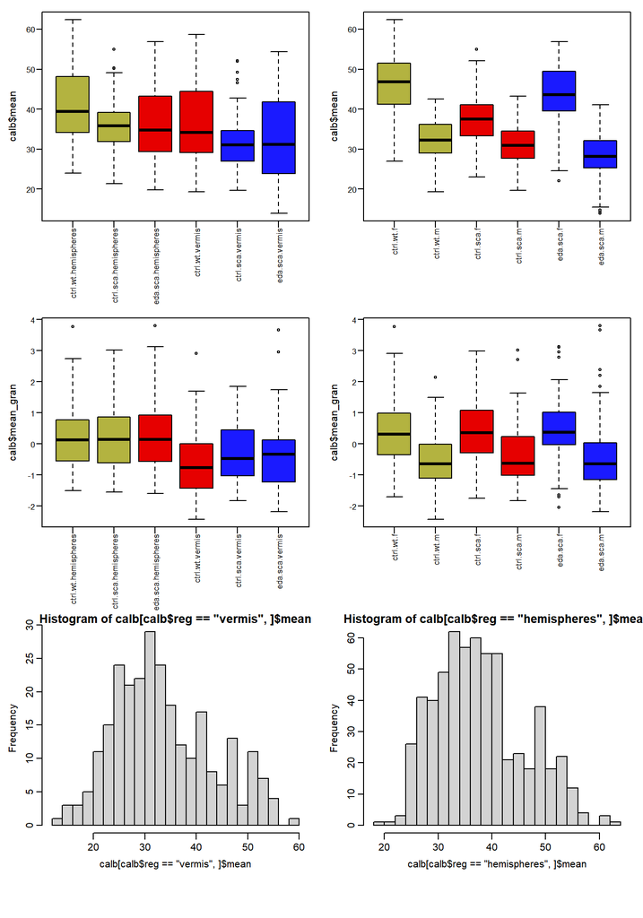

```r
## setting spacing

par(mfrow=c(3,2))
par(mar=c(7,3.5,1,1))
par(mgp=c(2,0.6,0))

plot(calb$mean ~ calb$group_region,
     col=cola[c(1,1,3,3,4,4)],cex.axis=0.8, las=2, xlab='')

plot(calb$mean ~ calb$group_sex,
     col=cola[c(1,1,3,3,4,4)],cex.axis=0.8, las=2, xlab='')

plot(calb$mean_gran ~ calb$group_region,
     col=cola[c(1,1,3,3,4,4)],cex.axis=0.8, las=2, xlab='')

plot(calb$mean_gran ~ calb$group_sex,
     col=cola[c(1,1,3,3,4,4)],cex.axis=0.8, las=2, xlab='')

hist(calb[calb$reg == 'vermis',]$mean,20)
hist(calb[calb$reg == 'hemispheres',]$mean,20)
```

*Calb IF* seems smaller in vermis and in males. The same patters are also seen in granular layers (GL). Distribution is slightly asymmetric and cannot go belong 0. Thus, gamma regression will be compared with Gaussian model

Is there correlation between GL and ML *calb IF* within individuals?

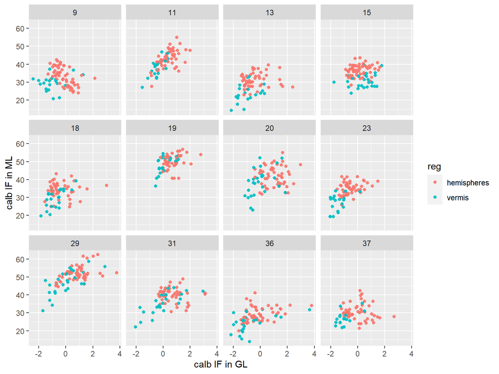

```r
calb %>% ggplot(aes(x = mean_gran, y=mean, col=reg)) +
  geom_point(alpha = 0.9)+
  facet_wrap(~id) +
  labs(x = "calb IF in GL", y = "calb IF in ML")
```

The correlation is seen in most individuals. Both covariates that vary across individuals (*calb IF* in GL and *region*) will thus be included as a covariate. Due to small sample size, we will not include sex in default, but the model with sex will be compared with this without sex.

# 4 Modelling

We will use gamma regression, with above-mentioned covariates. As there are multiple measurements per slice and region (4 for hemisphere), we will used hierarchical model with random intercepts of *slice* nested in *individual*

## 4.1 Prior specification

Summary statistics for prior

```r
## gamma
log(mean(calb$mean))
```

```
[1] 3.598145
```

```r
sd(log(calb$mean))*5
```

```
[1] 1.244363
```

```r
## Gaussian

mean(calb$mean)
```

```
[1] 36.53042
```

```r
sd(calb$mean)*c(5, 2, 1.2)
```

```
[1] 44.44635 17.77854 10.66713
```

```r
sd(calb$mean_gran, na.rm=TRUE)*1.2
```

```
[1] 1.2
```

Setting priors

```r
calb$group<-relevel(calb$group,ref='ctrl.sca')

## Gaussian
prior01 <- c(set_prior("student_t(3, 37, 44)", class = "b", coef = "Intercept"),
             set_prior("normal(0,18)", class = "b", coef = "groupctrl.wt"),
             set_prior("normal(0, 11)"  , class = "b", coef = "groupeda.sca"),
             set_prior("normal(0, 11)", class = "b", coef = "regvermis"),
             set_prior("normal(0, 5.5)", class = "b", coef = "mean_gran"))

## gamma
prior2 <- c(set_prior("student_t(3, 3.6, 1.24)", class = "b", coef = "Intercept"),
             set_prior("normal(0, 2)", class = "b", coef = "groupctrl.wt"),
             set_prior("normal(0, 1.2)", class = "b", coef = "groupeda.sca"),
             set_prior("normal(0 ,1.2)", class = "b", coef = "regvermis"),
             set_prior("normal(0, 1.2)", class = "b", coef = "mean_gran"))
```

## 4.2 Models fitting and diagnostics

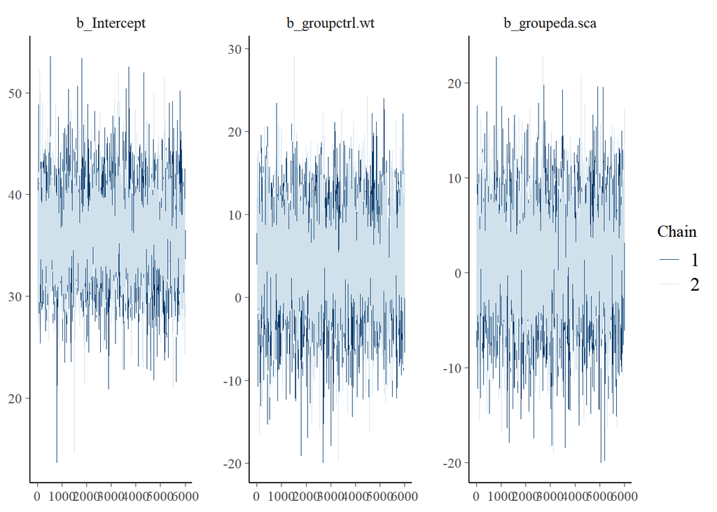

```r
## Gaussian
calb_model1 <- run_model(
                brm(mean~0+Intercept+group+reg + mean_gran + (1|id/slice_id),
                       data=calb, prior = prior01,
                       family=gaussian(),
                       save_pars = save_pars(all = TRUE),
                       iter=8000, warmup=2000,chains=2,cores=2,seed=17,
                       control = list(adapt_delta = 0.99)),
                       'output/brm/calb_model1', reuse = TRUE)

## Gamma
calb_model2 <- run_model(
            brm(mean ~0+Intercept+group+reg+ mean_gran + (1|id/slice_id),
                       data=calb, prior = prior2,
                       family=Gamma(link="log"),
                       save_pars = save_pars(all = TRUE),
                       iter=8000, warmup=2000,chains=2,cores=2,seed=17,
                       control = list(adapt_delta = 0.99)),
                       'output/brm/calb_model2', reuse = TRUE)

## chains mixing and convergence
mcmc_trace(calb_model1, pars = c('b_Intercept',
                               'b_groupctrl.wt',
                               'b_groupeda.sca'))
```

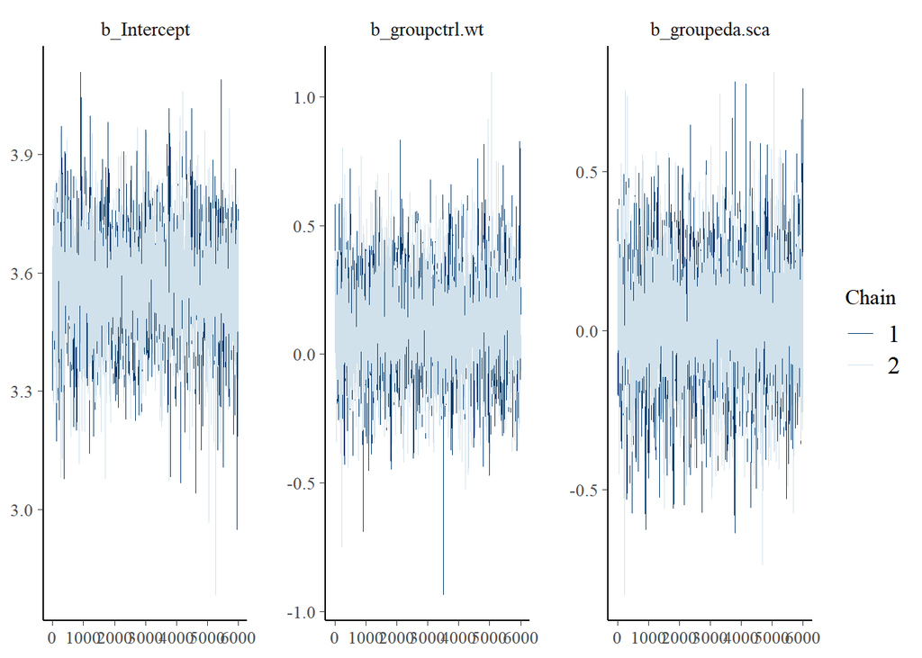

```r
mcmc_trace(calb_model2, pars = c('b_Intercept',
                               'b_groupctrl.wt',
                               'b_groupeda.sca'))
```

```r
## model summary
summary(calb_model1)
```

```
 Family: gaussian
  Links: mu = identity; sigma = identity
Formula: mean ~ 0 + Intercept + group + reg + mean_gran + (1 | id/slice_id)
   Data: calb (Number of observations: 868)
  Draws: 2 chains, each with iter = 8000; warmup = 2000; thin = 1;
         total post-warmup draws = 12000

Group-Level Effects:
~id (Number of levels: 12)
              Estimate Est.Error l-95% CI u-95% CI Rhat Bulk_ESS Tail_ESS
sd(Intercept)     8.04      1.97     5.16    12.73 1.00     4465     6934

~id:slice_id (Number of levels: 168)
              Estimate Est.Error l-95% CI u-95% CI Rhat Bulk_ESS Tail_ESS
sd(Intercept)     1.34      0.28     0.73     1.85 1.00     2855     2857

Population-Level Effects:
             Estimate Est.Error l-95% CI u-95% CI Rhat Bulk_ESS Tail_ESS
Intercept       36.00      3.80    28.52    43.59 1.00     3011     4955
groupctrl.wt     4.27      5.35    -6.50    14.70 1.00     3642     5494
groupeda.sca     1.13      4.95    -8.60    10.94 1.00     3820     5755
regvermis       -3.90      0.35    -4.59    -3.23 1.00    16240     9706
mean_gran        1.30      0.20     0.91     1.68 1.00    13563     9507

Family Specific Parameters:
      Estimate Est.Error l-95% CI u-95% CI Rhat Bulk_ESS Tail_ESS
sigma     4.35      0.12     4.13     4.60 1.00     6804     8215

Draws were sampled using sampling(NUTS). For each parameter, Bulk_ESS
and Tail_ESS are effective sample size measures, and Rhat is the potential
scale reduction factor on split chains (at convergence, Rhat = 1).
```

```r
summary(calb_model2)
```

```
 Family: gamma
  Links: mu = log; shape = identity
Formula: mean ~ 0 + Intercept + group + reg + mean_gran + (1 | id/slice_id)
   Data: calb (Number of observations: 868)
  Draws: 2 chains, each with iter = 8000; warmup = 2000; thin = 1;
         total post-warmup draws = 12000

Group-Level Effects:
~id (Number of levels: 12)
              Estimate Est.Error l-95% CI u-95% CI Rhat Bulk_ESS Tail_ESS
sd(Intercept)     0.23      0.07     0.14     0.40 1.00     3252     4928

~id:slice_id (Number of levels: 168)
              Estimate Est.Error l-95% CI u-95% CI Rhat Bulk_ESS Tail_ESS
sd(Intercept)     0.03      0.01     0.00     0.05 1.00     1888     2514

Population-Level Effects:
             Estimate Est.Error l-95% CI u-95% CI Rhat Bulk_ESS Tail_ESS
Intercept        3.56      0.12     3.33     3.80 1.00     2217     3565
groupctrl.wt     0.12      0.17    -0.22     0.46 1.00     2420     3834
groupeda.sca     0.03      0.17    -0.31     0.36 1.00     2369     3566
regvermis       -0.12      0.01    -0.14    -0.10 1.00    14103     9449
mean_gran        0.04      0.01     0.03     0.05 1.00    13372     9395

Family Specific Parameters:
      Estimate Est.Error l-95% CI u-95% CI Rhat Bulk_ESS Tail_ESS
shape    57.26      3.11    51.45    63.63 1.00     6199     7982

Draws were sampled using sampling(NUTS). For each parameter, Bulk_ESS
and Tail_ESS are effective sample size measures, and Rhat is the potential
scale reduction factor on split chains (at convergence, Rhat = 1).
```

Both models converged well.

## 4.3 PPC

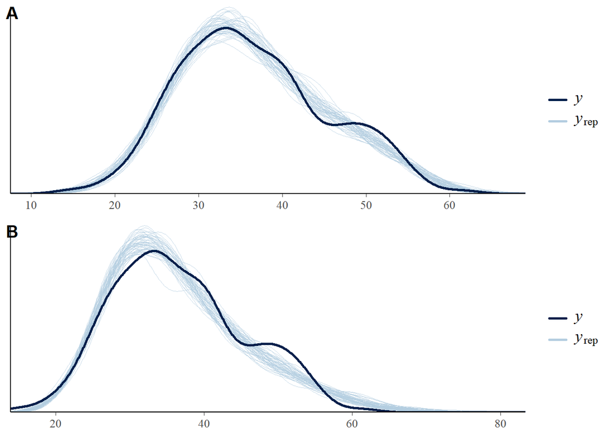

```r
pla<-pp_check(calb_model1,type='dens_overlay',ndraws = 50)
plb<-pp_check(calb_model2,type='dens_overlay',ndraws = 50)
plot_grid(pla, plb, labels=c("A", "B"), ncol = 1, nrow = 2)
```

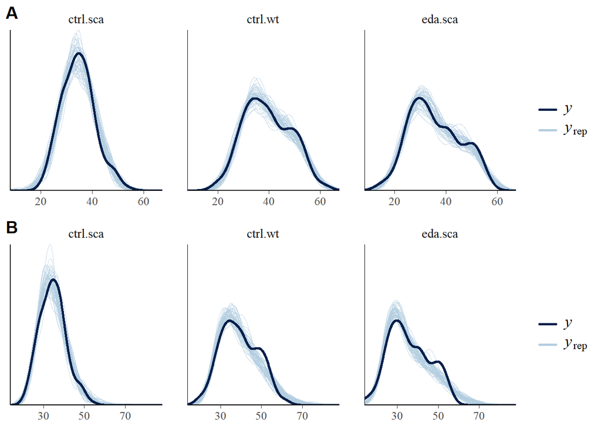

```r
pla<-pp_check(calb_model1,type='dens_overlay_grouped',ndraws = 50,group='group')
plb<-pp_check(calb_model2,type='dens_overlay_grouped',ndraws = 50,group='group')
plot_grid(pla, plb, labels=c("A", "B"), ncol = 1, nrow = 2)
```

```r
pla<-pp_check(calb_model1,type='scatter_avg')
```

```
Using all posterior draws for ppc type 'scatter_avg' by default.
```

```r
plb<-pp_check(calb_model2,type='scatter_avg')
```

```
Using all posterior draws for ppc type 'scatter_avg' by default.
```

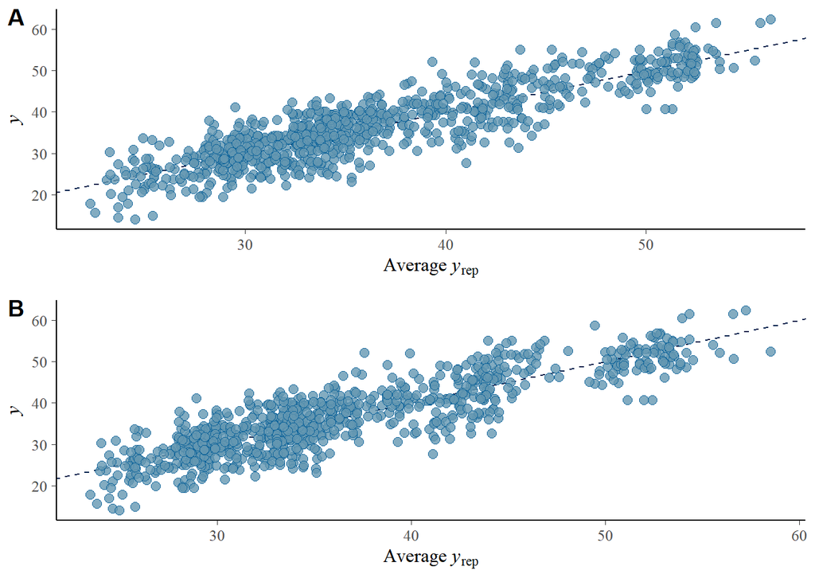

```r
plot_grid(pla, plb, labels=c("A", "B"), ncol = 1, nrow = 2)
```

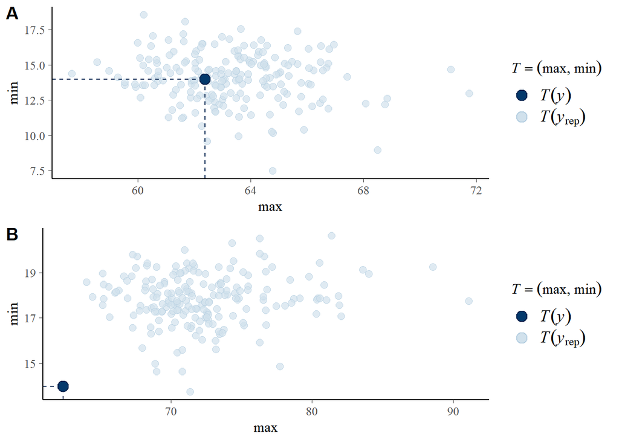

```r
pla<-pp_check(calb_model1,type="stat_2d", stat = c("max", "min"),ndraws=200)
plb<-pp_check(calb_model2,type="stat_2d", stat = c("max", "min"),ndraws=200)
plot_grid(pla, plb, labels=c("A", "B"), ncol = 1, nrow = 2)
```

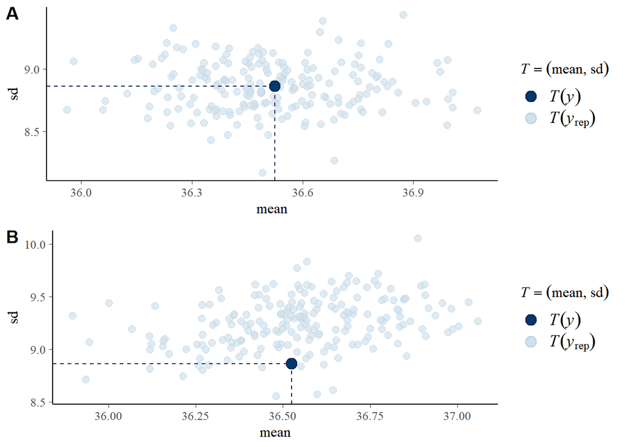

```r
pla<-pp_check(calb_model1,type="stat_2d", stat = c("mean", "sd"),ndraws=200)
plb<-pp_check(calb_model2,type="stat_2d", stat = c("mean", "sd"),ndraws=200)
plot_grid(pla, plb, labels=c("A", "B"), ncol = 1, nrow = 2)
```

```r
### Are there too influential observations?
par(mfrow=c(1,2))
plot(loo(calb_model1));loo(calb_model1)
```

```
Computed from 12000 by 868 log-likelihood matrix

         Estimate   SE
elpd_loo  -2542.2 21.0
p_loo        65.1  3.1
looic      5084.3 42.0
------
Monte Carlo SE of elpd_loo is 0.1.

All Pareto k estimates are good (k < 0.5).
See help('pareto-k-diagnostic') for details.
```

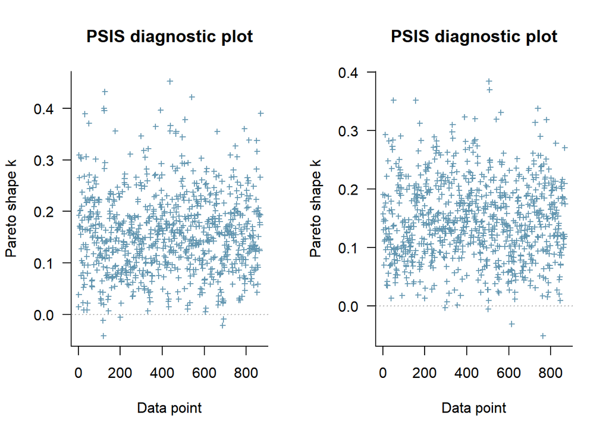

```
Computed from 12000 by 868 log-likelihood matrix

         Estimate   SE
elpd_loo  -2597.7 23.1
p_loo        44.2  2.4
looic      5195.4 46.1
------
Monte Carlo SE of elpd_loo is 0.1.

All Pareto k estimates are good (k < 0.5).
See help('pareto-k-diagnostic') for details.
```

```r
plot(loo(calb_model2));loo(calb_model2)
```

No serious issues detected. Gaussian model shows suprisingly better properties and fits the data better. Gaussian likelihood thus will be used.

What about inclusion of sex?

```r
## prior
prior03 <- c(set_prior("student_t(3, 37, 44)", class = "b", coef = "Intercept"),
             set_prior("normal(0,18)", class = "b", coef = "groupctrl.wt"),
             set_prior("normal(0, 11)"  , class = "b", coef = "groupeda.sca"),
             set_prior("normal(0, 11)", class = "b", coef = "regvermis"),
             set_prior("normal(0, 5.5)", class = "b", coef = "mean_gran"),
             set_prior("normal(0, 11)", class = "b", coef = "sex_num"))

## model fit
calb_model3 <- run_model(
                brm(mean~0+Intercept+group+reg + mean_gran +
                      sex_num + (1|id/slice_id),
                       data=calb, prior = prior03,
                       family=gaussian(),
                       save_pars = save_pars(all = TRUE),
                       iter=8000, warmup=2000,chains=2,cores=2,seed=17,
                       control = list(adapt_delta = 0.99)),
                       'output/brm/calb_model3', reuse = TRUE)

summary(calb_model3)
```

```
 Family: gaussian
  Links: mu = identity; sigma = identity
Formula: mean ~ 0 + Intercept + group + reg + mean_gran + sex_num + (1 | id/slice_id)
   Data: calb (Number of observations: 868)
  Draws: 2 chains, each with iter = 8000; warmup = 2000; thin = 1;
         total post-warmup draws = 12000

Group-Level Effects:
~id (Number of levels: 12)
              Estimate Est.Error l-95% CI u-95% CI Rhat Bulk_ESS Tail_ESS
sd(Intercept)     5.02      1.43     3.00     8.48 1.00     4217     6240

~id:slice_id (Number of levels: 168)
              Estimate Est.Error l-95% CI u-95% CI Rhat Bulk_ESS Tail_ESS
sd(Intercept)     1.34      0.29     0.72     1.87 1.00     2802     3254

Population-Level Effects:
             Estimate Est.Error l-95% CI u-95% CI Rhat Bulk_ESS Tail_ESS
Intercept       35.85      2.48    30.99    40.88 1.00     4511     5985
groupctrl.wt     4.59      3.57    -2.68    11.58 1.00     4359     5414
groupeda.sca     1.41      3.37    -5.23     8.21 1.00     4926     6063
regvermis       -4.04      0.36    -4.74    -3.34 1.00    17890    10043
mean_gran        1.26      0.20     0.86     1.65 1.00    14628    10471
sex_num        -10.17      2.99   -15.79    -3.94 1.00     5241     6103

Family Specific Parameters:
      Estimate Est.Error l-95% CI u-95% CI Rhat Bulk_ESS Tail_ESS
sigma     4.35      0.12     4.12     4.59 1.00     8165     7650

Draws were sampled using sampling(NUTS). For each parameter, Bulk_ESS
and Tail_ESS are effective sample size measures, and Rhat is the potential
scale reduction factor on split chains (at convergence, Rhat = 1).
```

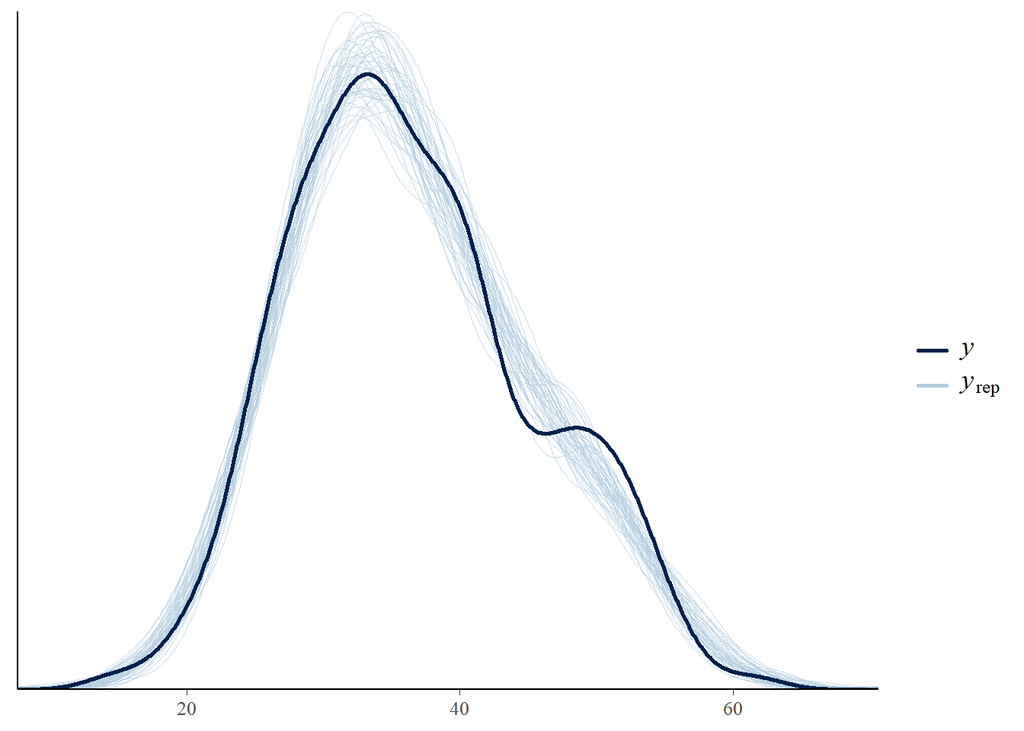

```r
pp_check(calb_model3,type='dens_overlay',ndraws = 50)
```

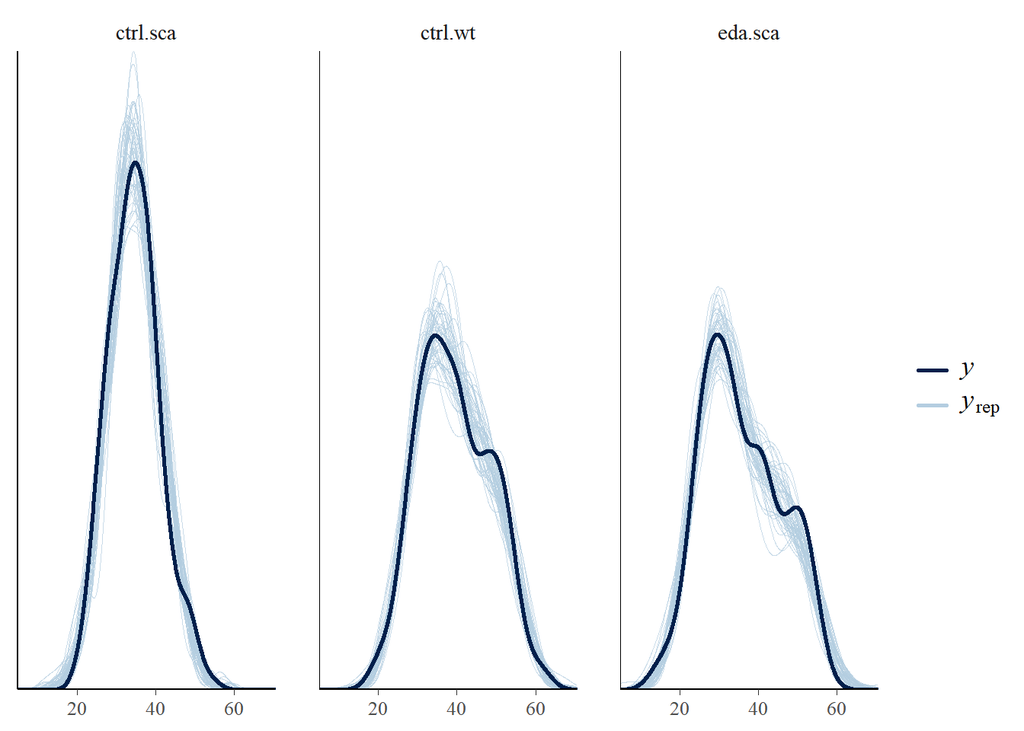

```r
pp_check(calb_model3,type='dens_overlay_grouped',ndraws = 50,group='group')
```

```
Using all posterior draws for ppc type 'scatter_avg' by default.
```

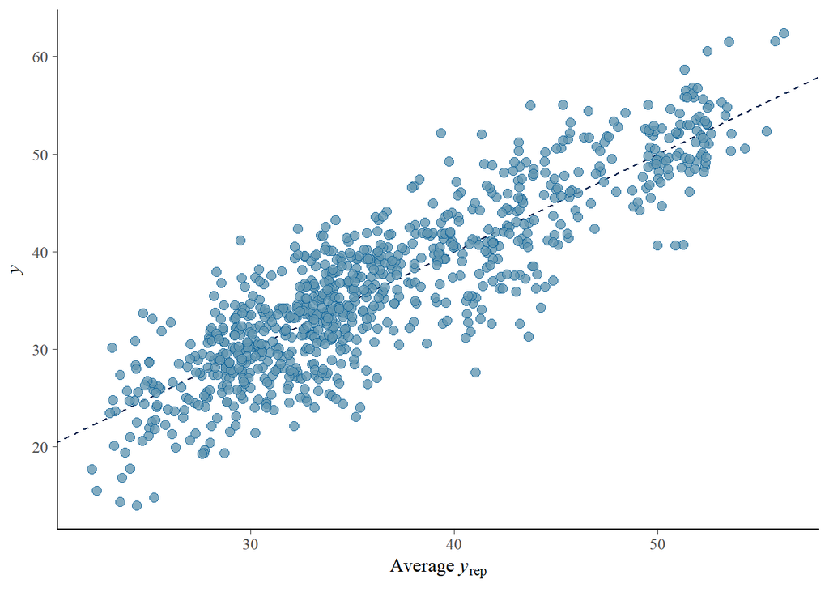

```r
pp_check(calb_model3,type='scatter_avg')
```

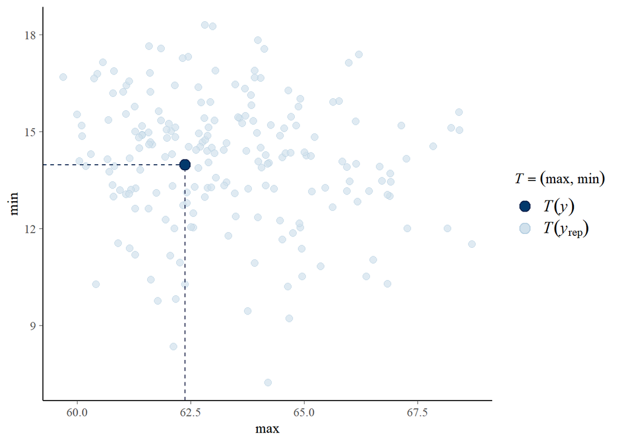

```r
pp_check(calb_model3,type="stat_2d", stat = c("max", "min"),ndraws=200)
```

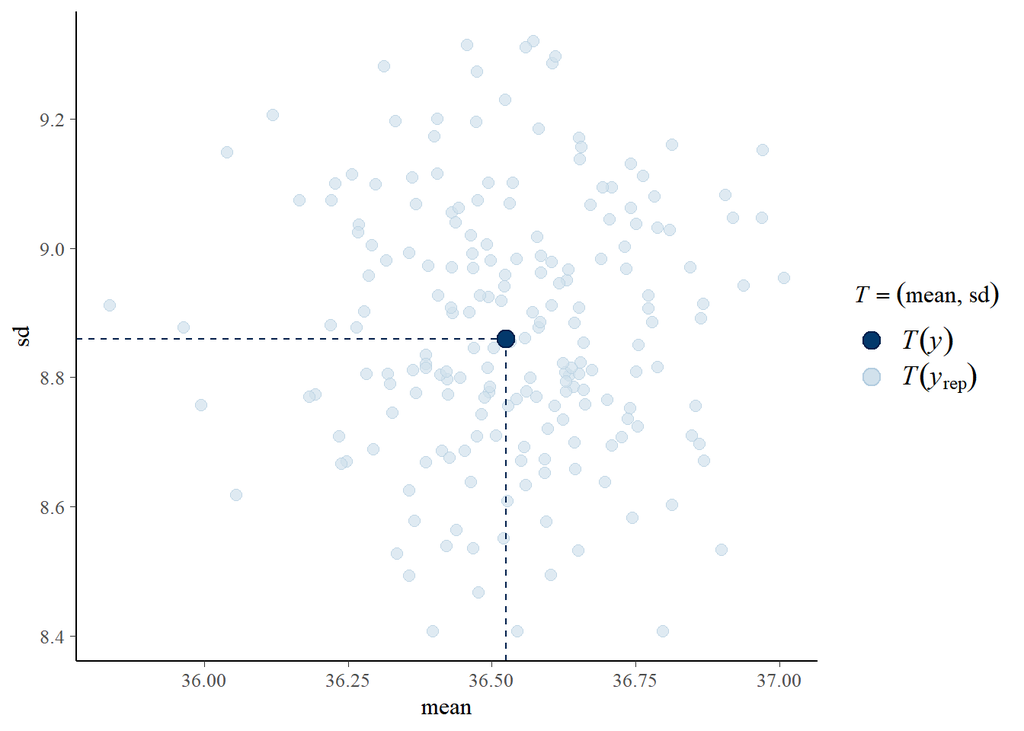

```r
pp_check(calb_model3,type="stat_2d", stat = c("mean", "sd"),ndraws=200)
```

Rhat , ESS and PPC are OK

Lets to compare the predictive accuracy of model with sex

## 4.4 Models comparison

```r
calb_model1 <- add_criterion(calb_model1, criterion = "loo")
calb_model3 <- add_criterion(calb_model3, criterion = "loo")

loo_compare(calb_model1, calb_model3)
```

```
            elpd_diff se_diff
calb_model1  0.0       0.0
calb_model3 -0.2       0.5
```

There is not evidence of improved accuracy via inclusion of sex, possibly due to inclusion of the covariate *Calbindin IF - GL* which was also different for males and females and arelady provides some adjustment. Model without sex will be used as the final model.

## 4.5 Posterior draws extraction

```r
post_fix_calb <- as.data.frame(calb_model1, variable = c("b_Intercept","b_groupctrl.wt",
                                                            "b_groupeda.sca"), )
names(post_fix_calb)[1]<-"sca_ctrl"

post_fix_calb$wt_ctrl<-post_fix_calb$sca_ctrl+post_fix_calb$b_groupctrl.wt
post_fix_calb$sca_eda<-post_fix_calb$sca_ctrl+post_fix_calb$b_groupeda.sca
summary(post_fix_calb)
```

```
    sca_ctrl     b_groupctrl.wt     b_groupeda.sca       wt_ctrl
 Min.   :13.62   Min.   :-19.9196   Min.   :-20.032   Min.   :20.48
 1st Qu.:33.55   1st Qu.:  0.8546   1st Qu.: -2.039   1st Qu.:37.73
 Median :35.95   Median :  4.2531   Median :  1.130   Median :40.25
 Mean   :36.00   Mean   :  4.2696   Mean   :  1.129   Mean   :40.27
 3rd Qu.:38.42   3rd Qu.:  7.7336   3rd Qu.:  4.382   3rd Qu.:42.78
 Max.   :53.62   Max.   : 29.0853   Max.   : 22.791   Max.   :56.71
    sca_eda
 Min.   :21.41
 1st Qu.:34.68
 Median :37.14
 Mean   :37.13
 3rd Qu.:39.53
 Max.   :54.66
```

```r
groupquant_calb <- sapply(post_fix_calb[,c(4,1,5)],
                          function(p) quantile(p, probs = c(0.025,0.975,0.5)))
```

# 5 Data and model visualization

In data visualization, individual points represent average per subject. Violin plot (area indicating data distribution) was, in contrast, constructed on the basis of individual data points (non-averaged)

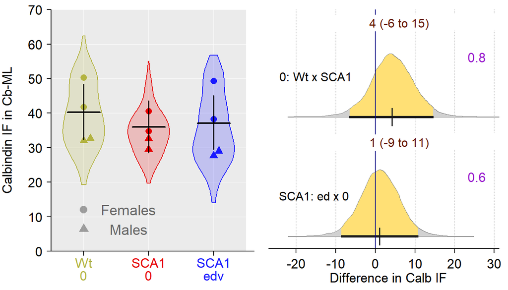

```r
suppressWarnings(suppressMessages( {
range<-c(0,70);scal<-range[2]-range[1]

par(mfrow=c(1,2))
par(mar=c(2,3,0,0))
par(mgp=c(2,0.6,0))


calb$group<-factor(calb$group,levels=c('ctrl.wt','ctrl.sca','eda.sca'))

xrange<-c(0.5,3.5);xscal=xrange[2]-xrange[1]
plot(NULL,xlim=c(xrange[1],xrange[2]),ylim=c(range[1],range[2]),xlab="",
     ylab="Calbindin IF in Cb-ML",las=1, axes=FALSE,cex.lab=1.1)

rect(xrange[1],range[2],xrange[2],range[1],col="grey92",border=NA)
x<-range[1]
repeat{
  lines(c(xrange[1],xrange[2]),c(x,x),col="white",lwd=0.7)
  x=x+10;if(x>range[2]){break}}

x<-1
repeat{
  lines(c(x,x),c(range[1],range[2]),col="white",lwd=0.7)
  x=x+1;if(x>3.5){break}}

vioplot(calb$mean~calb$group,col=colb[-2],at=c(1:4),add=T,
        border=cola[-2],axes=FALSE,drawRect=F,lwd=1,wex=0.8)

calb_sum <- calb %>% group_by(id, group, sex_num) %>% summarize(mean = mean(mean))


beeswarm(calb_sum$mean~calb_sum$group,col=cola[-2],at=c(1:3),
         add=T,pwpch=(16.5+calb_sum$sex_num), cex=1.2 )

tp<-(groupquant_calb[3,])
xx<-1;wid=0.25
repeat{
  lines(c(xx-wid,xx+wid),c(tp[xx],tp[xx]),lwd=2,col="black");
  lines(c(xx,xx),c(groupquant_calb[1,xx],groupquant_calb[2,xx]),lwd=1.7,col="black")
  xx<-xx+1
  if(xx>3){break}}

tckk=-0.02
axis(2,las=2,cex.axis=1.1,at=seq(range[1],range[2],by=10),
     labels=c(rep("",length(seq(range[1],range[2],by=10)))),pos=xrange[1],tck=tckk)
axis(2,las=2,cex.axis=1.1,at=seq(range[1],range[2],by=10),pos=xrange[1],tck=tckk)

axis(side=1,las=1,cex.axis=1.1,at=c(seq(1,4,by=1)),
     labels=c(rep("",length(seq(1,4,by=1)))),pos=range[1],tck=tckk)
lines(c(xrange[1],xrange[2]),c(range[1],range[1]))
text(c(1:3),c(rep(range[1]-0.046*scal,3)),xpd=T,cex=1.1,col=cola[-2],
     c("Wt", "SCA1", "SCA1"))
ypo<-c(range[1]-0.1*scal,range[1]-0.1*scal)
text(c(1:4),c(ypo[1],ypo[2],ypo[1],ypo[2]),xpd=T,cex=1.1,col=cola[-2],
     c("0", "0", "edv"))

ypos<-12; xpos=1
points(xpos,ypos,pch=16,cex=1.4,col=rgb(0.4,0.4,0.4,alpha=0.6))
text(xpos+0.23*xscal,ypos,"Females",col="grey40",cex=1.2)
points(xpos,ypos-0.08*scal,pch=17,cex=1.4,col=rgb(0.4,0.4,0.4,alpha=0.6))
text(xpos+0.23*xscal,ypos-0.08*scal,"Males",col="grey40",cex=1.2)

### probability distributions --------
par(mar=c(2.2,1,0,0))
dif<-data.frame(post_fix_calb$b_groupeda.sca,
                post_fix_calb$b_groupctrl.wt)
dif<-(dif)

yla<-"Difference in Calb IF"
tckk=-0.018
ste<-seq(-30, 30,by=10)
mons_poste(dif,0)

zpos=seq(-0.05,1,1/2)
xx=1;ind=0.6;xpol<- -15

text(xpol,zpos[xx]+zpos[2]*ind,
     "SCA1: ed x 0 ",cex=1)
xx=xx+1

text(xpol,zpos[xx]+zpos[2]*ind,
     "0: Wt x SCA1",cex=1)

} ) )
```